# Soluções: Atividade Prática 6

Econometria Aplicada à Finanças  
Mestrado Profissional em Administração

Autor

Prof. Dr. Washington S. da Silva

Data de Publicação

20 de outubro de 2026

## Questão 1

A série `Nile`, disponível no pacote `datasets` do R, registra o fluxo anual do rio Nilo em Assuã entre 1871 e 1970, medido em $10^8\,m^3$.

Essa série constitui um exemplo clássico em aplicações de testes de mudança estrutural, pois apresenta uma alteração pronunciada em seu nível no final do século XIX, período associado à construção da primeira barragem de Assuã.

Nesta questão, investigaremos se a **média do fluxo anual do Nilo permaneceu estável ao longo da amostra**.

Inicialmente, carregue os dados e examine graficamente o comportamento da série.

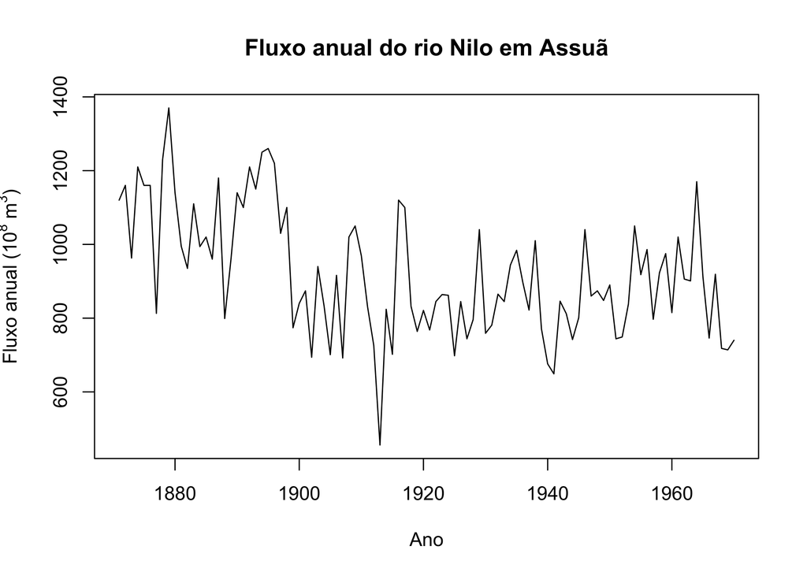

```r
# Carrega a série anual do fluxo do rio Nilo
# disponível no pacote datasets.
data("Nile", package = "datasets")

# Representa a série para examinar possíveis mudanças
# de nível ao longo do tempo.
plot(
  Nile,
  type = "l",
  xlab = "Ano",
  ylab = expression("Fluxo anual (" * 10^8 * " m"^3 * ")"),
  main = "Fluxo anual do rio Nilo em Assuã"
)
```

Considere o seguinte modelo:

```r
# Estima um modelo com apenas intercepto para
# representar o nível médio da série.
modelo_nilo <- lm(Nile ~ 1)
```

Como o modelo `Nile ~ 1` contém apenas o intercepto, esse intercepto representa a média do fluxo anual do Nilo. Portanto, nesta aplicação, avaliar a estabilidade dos parâmetros equivale a investigar se essa média permaneceu constante ao longo da amostra.

### **a)**

Utilize o método OLS-CUSUM para avaliar a estabilidade da média do fluxo anual do Nilo.

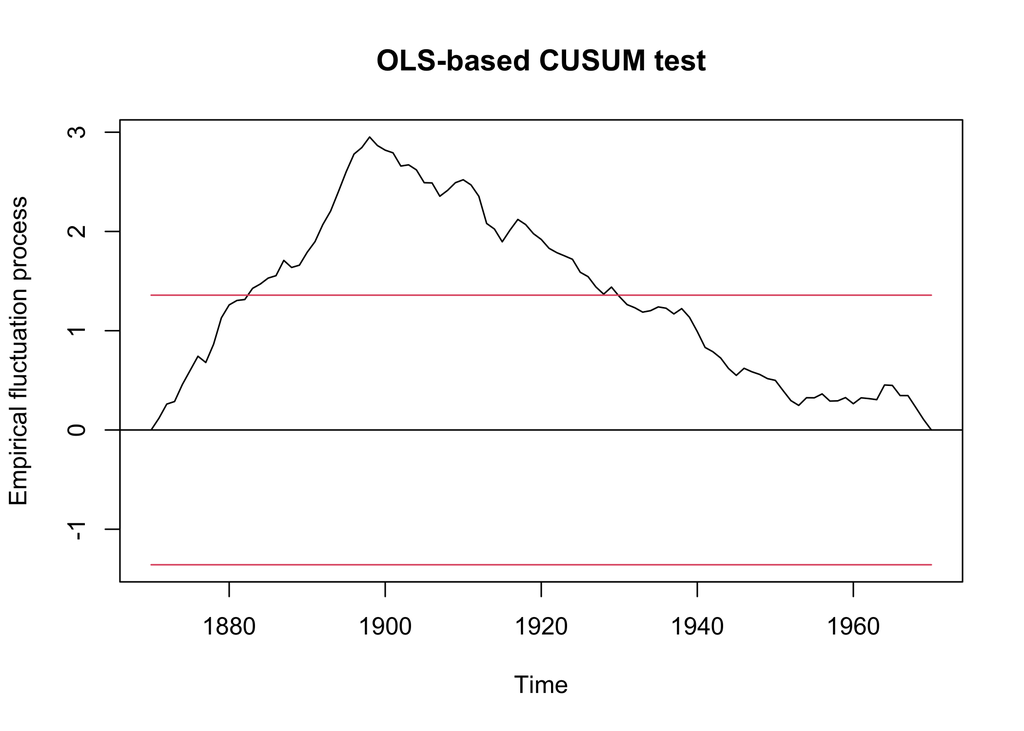

```r
# Calcula o processo OLS-CUSUM para avaliar a
# estabilidade da média.
cusum_nilo <- strucchange::efp(
  formula(modelo_nilo),
  type = "OLS-CUSUM"
)

# Representa o processo OLS-CUSUM com os
# limites críticos de 5%.
plot(cusum_nilo, alpha = 0.05)
```

```r
# Calcula a estatística e o valor-p do
# teste OLS-CUSUM.
resultado_cusum <- strucchange::sctest(cusum_nilo)

# Exibe a estatística e o valor-p do teste.
resultado_cusum
```

```
    OLS-based CUSUM test

data:  cusum_nilo
S0 = 2.95, p-value = 0.000000054
```

Com base nos resultados:

- verifique se o processo OLS-CUSUM ultrapassa algum dos limites críticos;
- informe a estatística do teste e seu valor-p;
- ao nível de significância de 5%, há evidência contra a hipótese de estabilidade da média do fluxo anual do Nilo?

Justifique sua conclusão utilizando conjuntamente o gráfico e o resultado do teste.

**DicaResposta**

O processo OLS-CUSUM ultrapassa o limite crítico superior de 5%. O teste produz $S_0 \approx 2{,}9518$ e valor-$p \approx 5{,}4 \times 10^{-8}$.

Como o valor-$p$ é muito inferior a 0,05, rejeitamos a hipótese nula de estabilidade. O gráfico e o teste formal fornecem evidência estatística de que a média do fluxo anual do Nilo não permaneceu constante ao longo da amostra.

### **b)**

Agora, utilize o teste supF para investigar uma possível mudança abrupta na média quando o ponto de quebra não é especificado a priori.

```r
# Calcula as estatísticas F para as divisões candidatas da amostra,
# utilizando trimming de 15% nas extremidades.
estatisticas_f <- strucchange::Fstats(
  formula(modelo_nilo),
  from = 0.15
)

# Aplica o teste supF para uma quebra com
# localização desconhecida.
resultado_supf <- strucchange::sctest(
  estatisticas_f,
  type = "supF"
)

# Exibe a estatística e o valor-p do teste.
resultado_supf
```

```
    supF test

data:  estatisticas_f
sup.F = 75.9, p-value = 0.00000000000000022
```

```r
# Localiza a divisão associada ao maior
# valor das estatísticas F.
quebra_nilo <- strucchange::breakpoints(estatisticas_f)

# Exibe a localização estimada da quebra.
quebra_nilo
```

```
     Optimal 2-segment partition:

Call:
breakpoints.Fstats(obj = estatisticas_f)

Breakpoints at observation number:
28

Corresponding to breakdates:
1898
```

Com base nos resultados:

- informe a estatística supF e seu valor-p e conclua, ao nível de significância de 5%, se há evidência de uma mudança abrupta na média;
- identifique o ano associado à quebra estimada e indique em que anos terminam e começam, respectivamente, o primeiro e o segundo regimes;
- relacione a localização encontrada ao contexto histórico apresentado no início da questão. Essa proximidade temporal é suficiente, por si só, para estabelecer que a construção da barragem causou a mudança?
- compare brevemente a conclusão do teste supF com aquela obtida pelo OLS-CUSUM no item (a).

**DicaResposta**

O teste produz $\operatorname{supF} \approx 75{,}93$ e um valor-$p$ extremamente pequeno, aproximadamente $2{,}22 \times 10^{-16}$. Portanto, rejeitamos a hipótese de estabilidade a 5% e concluímos que há evidência de uma mudança abrupta na média do fluxo anual.

A divisão estimada está na observação 28, correspondente a 1898. Pela convenção utilizada, 1898 é a última observação do primeiro regime e 1899 é a primeira do segundo.

A localização é temporalmente próxima ao período associado à construção da primeira barragem de Assuã. Essa proximidade pode orientar a interpretação histórica, mas não demonstra, por si só, que a barragem causou a mudança.

OLS-CUSUM e supF fornecem evidência consistente contra a estabilidade. O OLS-CUSUM avalia a estabilidade ao longo da amostra, mas não data formalmente a quebra. O supF testa uma mudança abrupta com ponto desconhecido; a sequência de estatísticas $F$, por meio de `breakpoints(estatisticas_f)`, permite localizar a divisão associada à maior estatística $F$.